# Fibroblast and cardiomyocyte trajectory

#### We conducted a trajectory analysis of fibroblast (Fib) and cardiomyocyte (CM) in the integrated data.

#### There are three parts in this markdown file: 1) integration of all Fib and CM cells; 2) trajectory analysis by slingshot; 3) confusion matrix between clusters of Fib/CM in the integrated data and clusters from this study.

#### The integration of Fib and CM was performed in Phate package. Louvain clustering was applied in the integrated data. Cell types and stages were showed in the integrated Phate embedding (Figure 1.1-1.2).

#### The trajectory analysis was performed by slingshot based on clusters in the integrated data (Figure 2.1).

#### The clusters in the integrated data were compared to clusters from this study (Figure 3.1).

#### The distribution of developmental stages were showed in each cluster in the integrated data (Figure 3.2).

```r
# Space separator
```

#### 1. Embed fibroblast and cardiomyocyte in integrated data by Phate

```r
# CM + Fib + CNCC
cfc_cl <- rownames(seu_clu)[seu_clu[, 1] %in% c(1:3, 8, 10)]  # 46203, take from the integrated data
cfc_mx <- lapply(mg_mx, function(x) {
    x[, colnames(x) %in% cfc_cl]
})
# remove CNCC
cncc <- cfc_cl[all_meta[cfc_cl, 3] %in% c("CM4-Melan", "NE", "Cardiac neural crest cells ")]  # 595
cf_mx <- sapply(cfc_mx, function(x) {
    x[, !colnames(x) %in% cncc]
})

# Seurat
library(Seurat)
seu <- lapply(cf_mx, function(x) {
    CreateSeuratObject(x, min.cells = 0, min.features = 0)
})
seu <- mapply(function(x, y) {
    if (y)
        x <- NormalizeData(x)
    x <- FindVariableFeatures(x, selection.method = "vst", nfeatures = 1000)
}, x = seu, y = rep(T, 5))
length(features <- SelectIntegrationFeatures(object.list = seu, nfeatures = 1000))
length(features <- setdiff(features, vis_rmg))
seu <- lapply(X = seu, FUN = function(x) {
    x <- ScaleData(x, features = features, verbose = FALSE)
    x <- RunPCA(x, features = features, verbose = FALSE)
})
anchor <- FindIntegrationAnchors(object.list = seu, anchor.features = features,
    reduction = "rpca", dims = 1:50, reference = 3)
seu_comb <- IntegrateData(anchorset = anchor)
DefaultAssay(seu_comb) <- "integrated"
# Run the standard workflow for visualization and clustering
seu_comb <- ScaleData(seu_comb, verbose = FALSE)
seu_comb <- RunPCA(seu_comb, npcs = 50, verbose = FALSE, features = features)
seu_comb <- RunUMAP(seu_comb, reduction = "pca", dims = 1:30)
cf_umap <- seu_comb@reductions$umap@cell.embeddings
cf_pcac <- seu_comb@reductions$pca@cell.embeddings
cf_hvg <- features

# identify clusters in Seurat
seu_comb <- FindNeighbors(seu_comb, dims = 1:30)
cf_clus <- rep(0, nrow(cf_umap))
resos <- seq(0.1, 1, 0.1)
for (reso in resos) {
    seu_comb <- FindClusters(seu_comb, resolution = reso, dims.use = 1:30)
    one_res <- as.numeric(seu_comb@active.ident)
    names(one_res) <- names(seu_comb@active.ident)
    cf_clus <- cbind(cf_clus, one_res)
}
cf_clus <- cf_clus[, -1]
colnames(cf_clus) <- resos
rownames(cf_clus) <- rownames(cf_umap)

# Phate on CM-Fib cells
library(phateR)
cf_phate <- phate(cf_pcac, knn = 20)  # input PCA, look at no PCA step when variables is less than 100?
# save( cf_phate,
# file='../etchevers/result/cf/cf_pcac_knn20_phate.rdata')
```

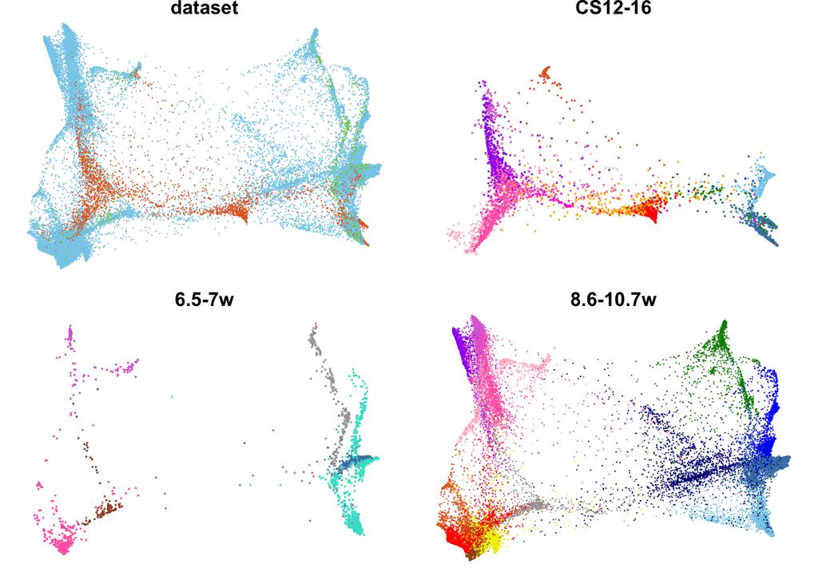

```r
cf_dr <- cf_phate$embedding
# pdf(paste('../etchevers/result/','cf/','glo_pcac_phate.pdf',sep=''),width=7,height=7)
# # by dataset
par(cex = 2, las = 1, mar = rep(0.7, 4), lwd = 3, mfrow = c(2, 2))
plot(cf_dr[rand_ind, 1], cf_dr[rand_ind, 2], pch = 16, xlab = "umap-1",
    ylab = "umap-2", frame = F, col = ds_col[as.character(all_meta[rownames(cf_dr),
        1])][rand_ind], cex = 0.2, xaxt = "n", yaxt = "n", xlim = range(cf_dr[,
        1]), ylim = range(cf_dr[, 2]), main = "dataset")
# legend( 'bottomleft', col=ds_col,
# legend=c('CS12-16','6.5-7w','8.6-10.7w'), xpd=NA, bty='n', pch=16,
# cex=1.5)
plot(cf_dr[rand_ind, 1], cf_dr[rand_ind, 2], pch = 16, xlab = "umap-1",
    ylab = "umap-2", frame = F, col = tp1_col[as.character(all_meta[rownames(cf_dr),
        3])][rand_ind], cex = 0.3, xaxt = "n", yaxt = "n", xlim = range(cf_dr[,
        1]), ylim = range(cf_dr[, 2]), main = "CS12-16")
# legend( 'topleft', col=tp1_col,
# legend=paste(1:15,c('SHF',names(tp1_col)[-c(1,15)],'splanchnic
# LPM-21')), xpd=NA, bty='n', pch=16, cex=.5)
plot(cf_dr[rand_ind, 1], cf_dr[rand_ind, 2], pch = 16, xlab = "umap-1",
    ylab = "umap-2", frame = F, col = tp2_col[as.character(all_meta[rownames(cf_dr),
        3])][rand_ind], cex = 0.3, xaxt = "n", yaxt = "n", xlim = range(cf_dr[,
        1]), ylim = range(cf_dr[, 2]), main = "6.5-7w")
# legend( 'topleft', col=tp2_col,
# legend=paste(1:length(tp2_col),names(tp2_col)), xpd=NA, bty='n',
# pch=16, cex=.5)
plot(cf_dr[rand_ind, 1], cf_dr[rand_ind, 2], pch = 16, xlab = "umap-1",
    ylab = "umap-2", frame = F, col = tp3_col2[as.character(all_meta[rownames(cf_dr),
        3])][rand_ind], cex = 0.2, xaxt = "n", yaxt = "n", xlim = range(cf_dr[,
        1]), ylim = range(cf_dr[, 2]), main = "8.6-10.7w")
```

```r
# dev.off()
```

##### Figure 1.1: Phate embedding of Fib and CM by dataset.

.

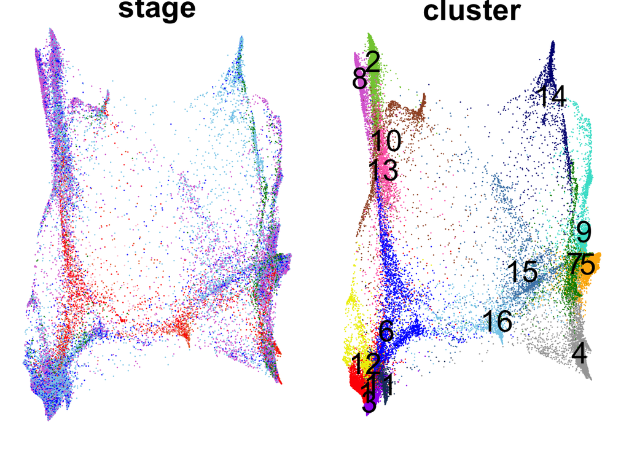

```r
# pdf(paste('../etchevers/result/','cf/','glo_phate_stage.pdf',sep=''),width=7,height=7)
# # by all stages
par(cex = 2, las = 1, mar = rep(0.7, 4), lwd = 3, cex.main = 2, mfrow = c(1,
    2))
plot(cf_dr[rand_ind, 1], cf_dr[rand_ind, 2], pch = 16, xlab = "umap-1",
    ylab = "umap-2", frame = F, col = st_col[as.character(all_meta[rownames(cf_dr),
        4])][rand_ind], cex = 0.2, xaxt = "n", yaxt = "n", main = "stage")
# legend( 'bottomright', col=st_col,
# legend=c(names(st_col)[1:3],'6.5-7w',names(st_col)[5:7]), xpd=NA,
# bty='n', pch=16, cex=.8) dev.off()

# seurat clusters on Phate
# pdf(paste('../etchevers/result/','cf/','glo_phate_seuclu.pdf',sep=''),
# width=8,height=12) # by Seurat clusters
par(cex = 2, las = 1, mar = rep(0.5, 4), lwd = 3, pch = 16, cex.main = 1)
i <- 4
plot_cen <- sapply(sort(unique(cf_clus[, i])), function(x) {
    cl <- rownames(cf_clus)[cf_clus[, i] == x]
    res <- c(median(cf_dr[cl, 1]), median(cf_dr[cl, 2]))
    return(res)
})
plot(cf_dr[rand_ind, 1], cf_dr[rand_ind, 2], pch = 16, xlab = "umap-1",
    ylab = "umap-2", frame = F, col = col6[-1][cf_clus[, i]][rand_ind],
    cex = 0.1, main = "cluster", xaxt = "n", yaxt = "n")
for (i in 1:ncol(plot_cen)) text(plot_cen[1, i], plot_cen[2, i], label = i,
    xpd = NA)
```

```r
# dev.off()
```

##### Figure 1.2: Stages and clusters on the Phate embedding.

.

#### 2. Slingshot trajectory

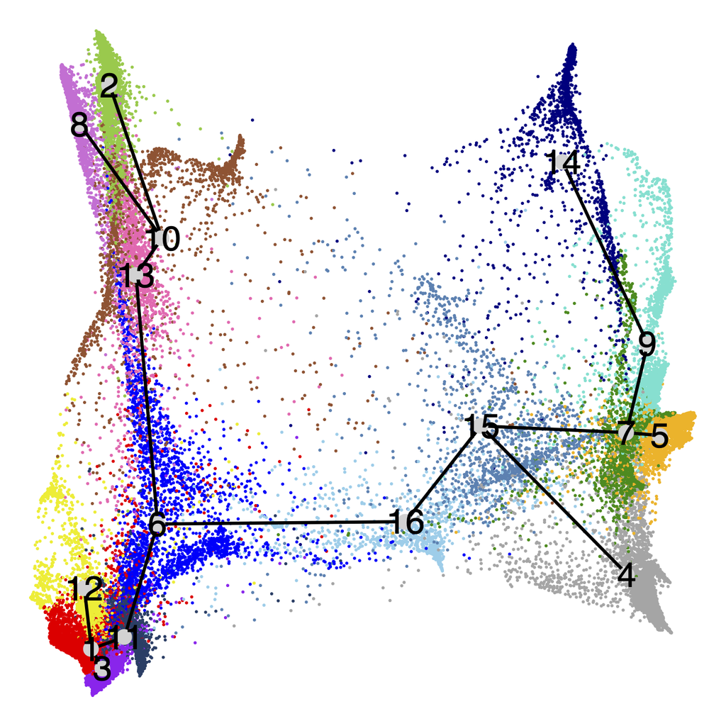

```r
library(slingshot)
cf_clu <- cf_clus[, 4]
cf_phate_lin <- getLineages(cf_dr, cf_clu)
cf_clu_ear <- tapply(names(cf_clu), cf_clu, function(x) {
    (sum(all_meta[x, 1] %in% "our") * 2 + sum(all_meta[x, 1] %in% "asp"))/length(x)
})
# pdf(paste('../etchevers/result/','cf/','glo_phate_slin.pdf',sep='')
# )
par(cex = 2, las = 1, mar = rep(0.1, 4), lwd = 3, pch = 16, xaxt = "n",
    yaxt = "n")
plot(cf_dr, col = col6[-1][cf_clu], frame = F, cex = 0.2)
lines(SlingshotDataSet(cf_phate_lin), lwd = 3, col = "black", cex = 0.01)
plot_cen <- sapply(names(cf_clu_ear), function(x) {
    c(mean(cf_dr[names(cf_clu)[cf_clu == x], 1]), mean(cf_dr[names(cf_clu)[cf_clu ==
        x], 2]))
})
clu_cex <- cf_clu_ear * 3
clu_cex[clu_cex < 1] <- 1
clu_cex[clu_cex > 2] <- 2
for (i in 1:ncol(plot_cen)) {
    # plot node size by percentage of early cells points(
    # plot_cen[1,i], plot_cen[2,i] , cex=clu_cex[i], col=col6[1] )
    points(plot_cen[1, i], plot_cen[2, i], cex = 1, col = col6[1])
}
for (i in 1:ncol(plot_cen)) text(plot_cen[1, i], plot_cen[2, i], label = i,
    cex = 1, col = "black", xpd = NA)
# dev.off()
```

##### Figure 2.1: slingshot trajectory on the Phate embedding.

.

#### 3. Confusion matrix between clusters of Fib/CM and original clusters

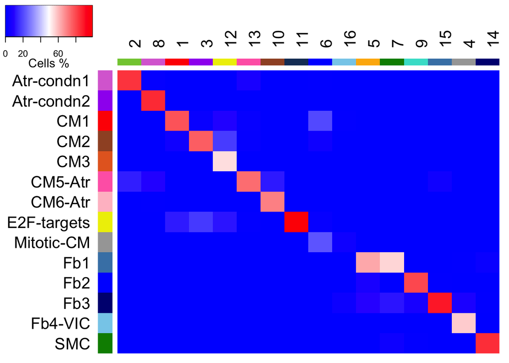

```r
etc_in <- etc_tp[c(1:2, 4:6, 8:10, 19, 14:17, 21)]
etc_in_clu <- sapply(sapply(etc_in, function(x) {
    rownames(all_meta)[all_meta[, 3] %in% x]
}), function(x) {
    sapply(tapply(names(cf_clu), cf_clu, function(x) {
        x
    }), function(y) {
        sum(x %in% y)
    })
})
plot_mx <- t(apply(etc_in_clu, 2, function(x) {
    x/sum(x)
}))  # by individual cluster
plot_mx <- apply(etc_in_clu, 1, function(x) {
    x/sum(x)
})  # by global cluster
plot_mx <- t(etc_in_clu * 100/as.numeric(tapply(names(cf_clu), cf_clu,
    length)))  # by global cluster, divide by total number of global clusters
plot_mx <- plot_mx[, order(apply(plot_mx, 2, which.max))]
# pdf(paste('../etchevers/result/','cf/','glo_clu_in_etc.pdf',sep='')
# )
tmp <- heatmap3(plot_mx, labRow = paste(rownames(plot_mx), "    "), scale = "none",
    dendrogram = "none", trace = "none", Rowv = F, Colv = F, symkey = F,
    density.info = "none", keysize = 1, col = colorRampPalette(c("blue",
        "white", "red"))(499), color_key_label = "Cells %", color_key_label_cex = 1,
    margins = c(1, 1), color_key_axis_cex = 1, key_mar = c(2, 0.5, 0.5,
        0.5), labCol = paste("   ", colnames(plot_mx)), labRow_pos = c(2),
    sepwidth = c(0.1, 0.1), sepcolor = "black", cexRow = 2, cexCol = 2,
    lhei = c(1, 5), labCol_las = 2, labCol_pos = 3, RowSideColors = tp3_col2[rownames(plot_mx)],
    ColSideColors = col6[-1][as.numeric(colnames(plot_mx))])
```

```r
# dev.off()
```

##### Figure 3.1: confusion matrix between clusters of Fib/CM in the integrated data and clusters from this study.

.

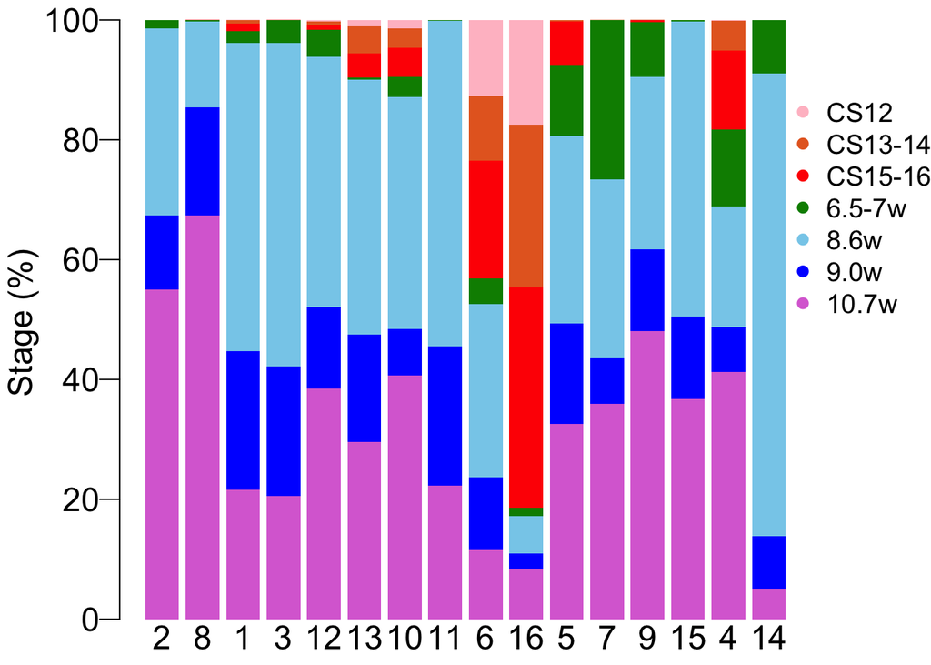

```r
# cells from each stage in each cluster
clu_st <- sapply(colnames(plot_mx), function(x) {
    res <- rep(0, 7)
    names(res) <- rev(names(st_col))
    st <- table(all_meta[names(cf_clu)[cf_clu == as.numeric(x)], 4])
    res[intersect(names(st), names(res))] <- st[intersect(names(st), names(res))]
    return(res)
})
# pdf(paste('../etchevers/result/','cf/','glo_clu_st.pdf',sep=''),height=3,
# )
par(cex = 1.5, las = 1, mar = c(1, 3, 0.5, 3), lwd = 3, mgp = c(2, 0.5,
    0))
bar <- barplot(apply(clu_st, 2, function(x) {
    x/sum(x) * 100
}), xlab = "", ylab = "Stage (%)", col = st_col[rownames(clu_st)], border = NA,
    names.arg = rep("", ncol(clu_st)))
text(bar, -3, label = colnames(clu_st), xpd = NA)
legend(19, 90, col = st_col, legend = c(names(st_col)[1:3], "6.5-7w", names(st_col)[5:7]),
    xpd = NA, bty = "n", pch = 16, cex = 0.8)
```

```r
# dev.off()
```

##### Figure 3.2: distribution of developmental stages in each cluster in the integrated data.